# Tiger Milkweed Butterflies (genus Danaus) Statistical Project

Julia Zheng & Kate Skocelas

10/15/2020

## Read in Raw Data

```r
setwd("C:\\Dropbox\\Classes\\Classes\\IBIO 830 stats\\project1")
#setwd("~/Desktop/stats/Project1/IBIO830---Statistical-Project")

# load raw data from csv file
butterfly_raw <- read.csv("Danaus.csv", header = TRUE)
```

```r
# Load required libraries
if (!require(RColorBrewer)) install.packages('RColorBrewer')
library(RColorBrewer)

if (!require(rworldmap)) install.packages('rworldmap')
library(rworldmap)

if (!require(scales)) install.packages('scales')
library(scales)

if (!require(dplyr)) install.packages('dplyr')
library(dplyr)

if (!require(ggplot2)) install.packages('ggplot2')
library(ggplot2)
```

## Data Cleaning and Exploration

```r
# Rename column where there is a typo
names(butterfly_raw)[names(butterfly_raw) == "phyenotype..metamorphosis.stage."] <- "metamorphosis_stage"

# check for NAs in the data
sum(is.na(butterfly_raw)) # 132 NAs found
```

```
## [1] 132
```

```r
# Remove NAs in the data columns we are looking at
butterfly_data <- butterfly_raw
butterfly_data <- butterfly_data[!is.na(butterfly_data$latitude),]
butterfly_data <- butterfly_data[!is.na(butterfly_data$longitude),]
butterfly_data <- butterfly_data[!is.na(butterfly_data$positional_accuracy),]
butterfly_data <- butterfly_data[!is.na(butterfly_data$scientific_name),]
butterfly_data <- butterfly_data[!is.na(butterfly_data$metamorphosis_stage),]
butterfly_data <- butterfly_data[!is.na(butterfly_data$observed_on),]
```

### Initial plotting

```r
# look at the data
head(butterfly_raw)
```

```
##       id observed_on_string observed_on time_observed_at
## 1  58506          10/1/2010   10/1/2010
## 2  59696         12/18/2010  12/18/2010
## 3  85603          5/31/2012   5/31/2012
## 4 318380          6/27/2013   6/27/2013
## 5 406353          9/23/2013   9/23/2013
## 6 416233          10/2/2013   10/2/2013
##                    time_zone user_id   user_login              created_at
## 1 Eastern Time (US & Canada)    5245  kent_miller 2012-03-17 22:57:24 UTC
## 2 Eastern Time (US & Canada)    5245  kent_miller 2012-03-24 14:09:09 UTC
## 3 Eastern Time (US & Canada)    5245  kent_miller 2012-06-01 12:53:39 UTC
## 4 Eastern Time (US & Canada)    5245  kent_miller 2013-07-02 13:45:24 UTC
## 5                  Monterrey   21332 oscar_almeda 2013-09-24 03:30:13 UTC
## 6                  Monterrey   21332 oscar_almeda 2013-10-03 03:53:08 UTC
##                updated_at quality_grade  license
```

[output cut: 76 more lines]

#### Metamorphic stage of samples

```r
# number of samples in each metamorphic stage
count(butterfly_data, butterfly_data$metamorphosis_stage)
```

```
##   butterfly_data$metamorphosis_stage   n
## 1                          butterfly 120
## 2                        caterpillar  25
## 3                          chrysalis   6
## 4                                egg   2
```

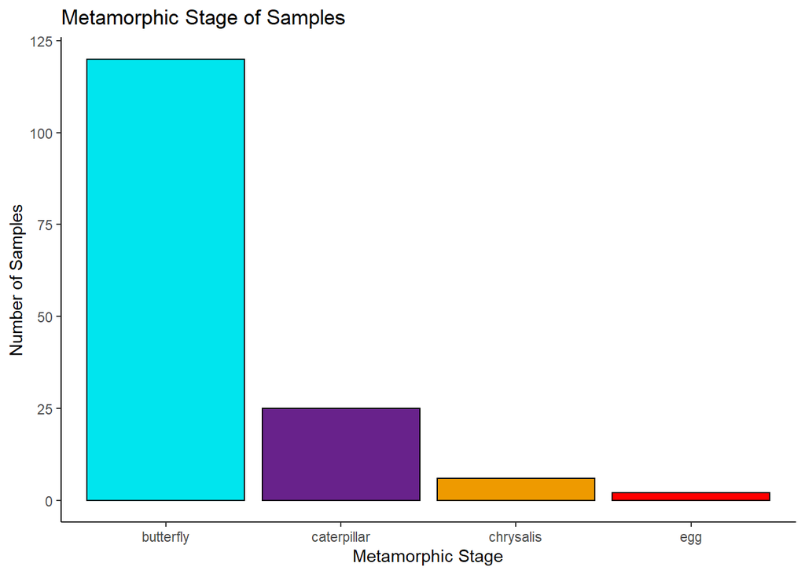

```r
# Create bar plot of metamorphic stage
ggplot(butterfly_data, aes(x=metamorphosis_stage))+
  geom_bar(col="black", fill= c("turquoise2", "darkorchid4", "orange2", "red"))+
  labs(x="Metamorphic Stage", y="Number of Samples", title="Metamorphic Stage of Samples")+
  theme_classic()
```

There are significantly more samples of organisms in the “butterfly” metamorphic stage than in any of the other metamorphic stages. This may represent a sampling bias in the dataset. Individuals in the “butterfly” stage may be easier for amateur naturalists to spot, or they may be more appealing to photograph and log. In the statistical tests section, we use a chi-squared goodness of fit test to test the null hypothesis that our data set does not accurately fit the expected average lifecyle durations of genus Danaus butterflies.

#### Metamorphic stage of sample compared to observation date

```r
# add year of observation to data frame
butterfly_data$year <- substr(butterfly_data$observed_on, nchar(butterfly_data$observed_on)-3 ,nchar(butterfly_data$observed_on))

# get the number of samples collected in each year
count(butterfly_data, butterfly_data$year)
```

```
##    butterfly_data$year  n
## 1                 2010  2
## 2                 2012  1
## 3                 2013  4
## 4                 2014  2
## 5                 2015  1
## 6                 2016  1
## 7                 2017 12
## 8                 2018 33
## 9                 2019 57
## 10                2020 40
```

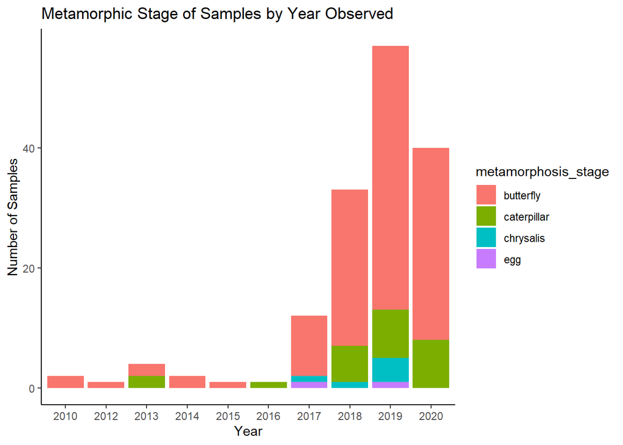

```r
#plot stage against year of observation
ggplot(butterfly_data, aes(x=year, fill=metamorphosis_stage))+
  geom_bar()+
  labs(x="Year", y="Number of Samples", title="Metamorphic Stage of Samples by Year Observed")+
  theme_classic()
```

The distribution of samples by year appears to follow the pattern expected by the rise in popularity of the iNaturalist website. We suspect that 2020 has fewer samples (so far) than 2019 because the year is not yet complete.

```r
# add month of observation to data frame
butterfly_data$month <- substr(butterfly_data$observed_on, 1,2)
for(i in 1:nrow(butterfly_data)) {
  month <- butterfly_data$month[i]
  last_letter <- substr(month, 2,2)
  if(last_letter == "/") {
    month <- substr(month, 1,1)
  }
  butterfly_data$month[i] <- month
}

# get the number of samples collected in each month
butterfly_data$month_fac <- factor(butterfly_data$month, levels=c("1","2","3","4","5","6","7","8","9","10","11","12"))
count(butterfly_data, butterfly_data$month_fac)
```

```
##    butterfly_data$month_fac  n
## 1                         1  3
## 2                         2  2
## 3                         3 14
## 4                         4 13
## 5                         5  3
## 6                         6 13
## 7                         7 20
## 8                         8 33
## 9                         9 20
## 10                       10 19
## 11                       11  9
## 12                       12  4
```

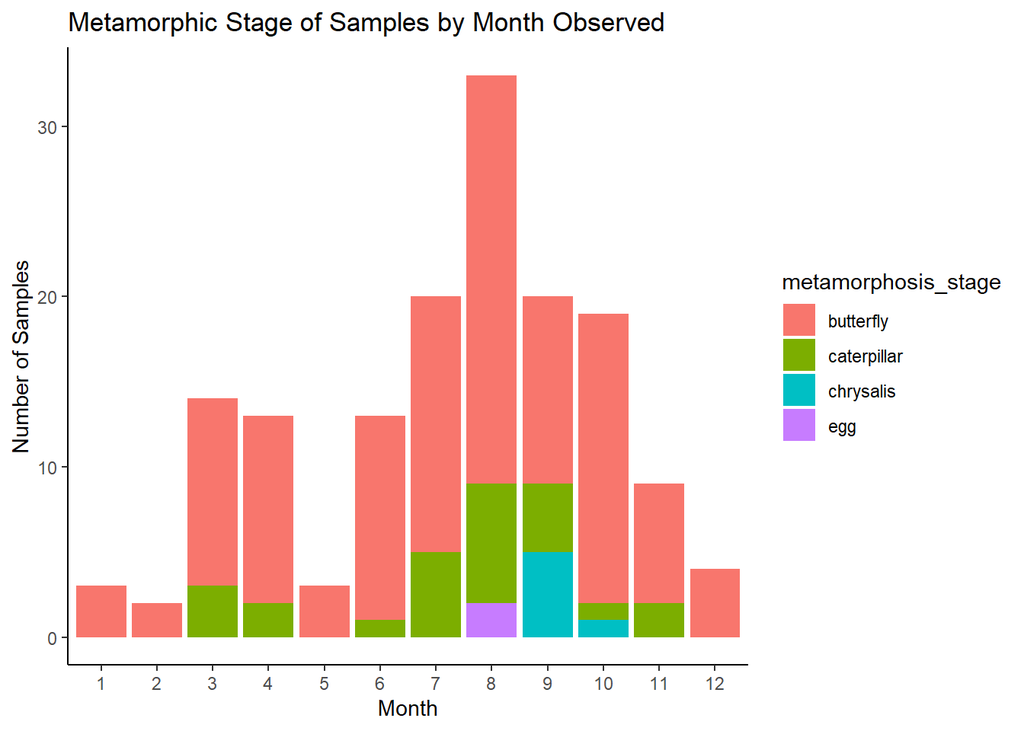

```r
#plot stage against month of observation
ggplot(butterfly_data, aes(x=month_fac, fill=metamorphosis_stage))+
  geom_bar()+
  labs(x="Month", y="Number of Samples", title="Metamorphic Stage of Samples by Month Observed")+
  theme_classic()
```

The observations appear to have a bimodal distribution. The first peak is in March, and the second peak is in August. If these two normal distributions exist, they may indicate the peak butterfly seasons in two distinct climates. In the statistical tests, we test the hypothesis that a sample’s observation month is related to the latitude of the observation location, because butterflies are most active in warm weather.

#### Positional accuracy vs. latitude and longitude

Positional accuracy in iNaturalist describes how far away the submitted observations are in meters from the recorded longitude and latitude coordinates. Therefore, it is important for us to look at whether our coordinate information is accurate to where the genus Danaus was observed and remove outliers with extremely poor accuracy (those with large positional accuracy values).

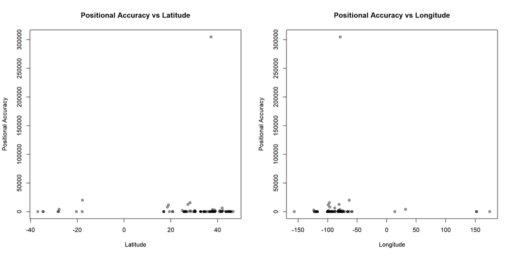

```r
par(mfrow=c(1,2))

# plot positional accuracy vs latitude
plot(butterfly_data$positional_accuracy ~butterfly_data$latitude,
     xlab = "Latitude",
     ylab = "Positional Accuracy",
     pch = 19,
     col = adjustcolor(1,0.4),
     main = "Positional Accuracy vs Latitude")

# plot positional accuracy vs longitude
plot(butterfly_data$positional_accuracy ~butterfly_data$longitude,
     xlab = "Longitude",
     ylab = "Positional Accuracy",
     pch = 19,
     col = adjustcolor(1,0.4),
     main = "Positional Accuracy vs Longitude")
```

There are some outliers in our data, in particular in the data points that contain latitude or longitude greater than 30,000 meters away from observations. We cleaned the data by removing data points that are more than 15,000 meters away from the recorded location.

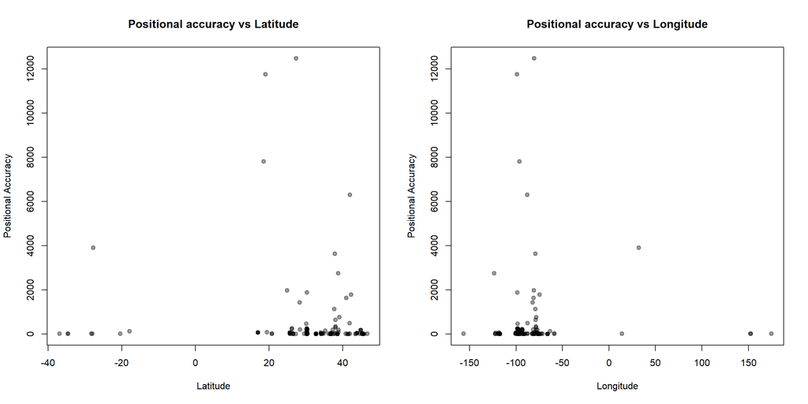

```r
# remove outliers
butterfly_data <- butterfly_data %>% filter(positional_accuracy < 15000)

par(mfrow=c(1,2))

# plot positional accuracy vs latitude
plot(butterfly_data$positional_accuracy ~butterfly_data$latitude,
     xlab = "Latitude",
     ylab = "Positional Accuracy",
     pch = 19,
     col = adjustcolor(1,0.4),
     main = "Positional accuracy vs Latitude")

# plot positional accuracy vs longitude
plot(butterfly_data$positional_accuracy ~butterfly_data$longitude,
     xlab = "Longitude",
     ylab = "Positional Accuracy",
     pch = 19,
     col = adjustcolor(1,0.4),
     main = "Positional accuracy vs Longitude")
```

By removing the outliers, the maximum positional accuracy present in our dataset is improved, and we can be more certain that our dataset’s longitude and latitude values are reasonably close to the actual observation locations.

### Species distribution across the world

#### Adding colours qualitatively with a library

```r
butterfly_data$scientific_name <- as.factor(butterfly_data$scientific_name)
# set up colors for butterflies
jColors <- with(butterfly_data,
                data.frame(scientific_name = levels(scientific_name),
                           color = I(brewer.pal(nlevels(scientific_name), name = 'Accent'))))
# set up new data frame for plot
butterfly_data_scatter <- data.frame(subset(butterfly_data, select = c(latitude, longitude, scientific_name)),
           matchRetVal = match(butterfly_data$scientific_name, jColors$scientific_name))
```

#### Plot points onto world map

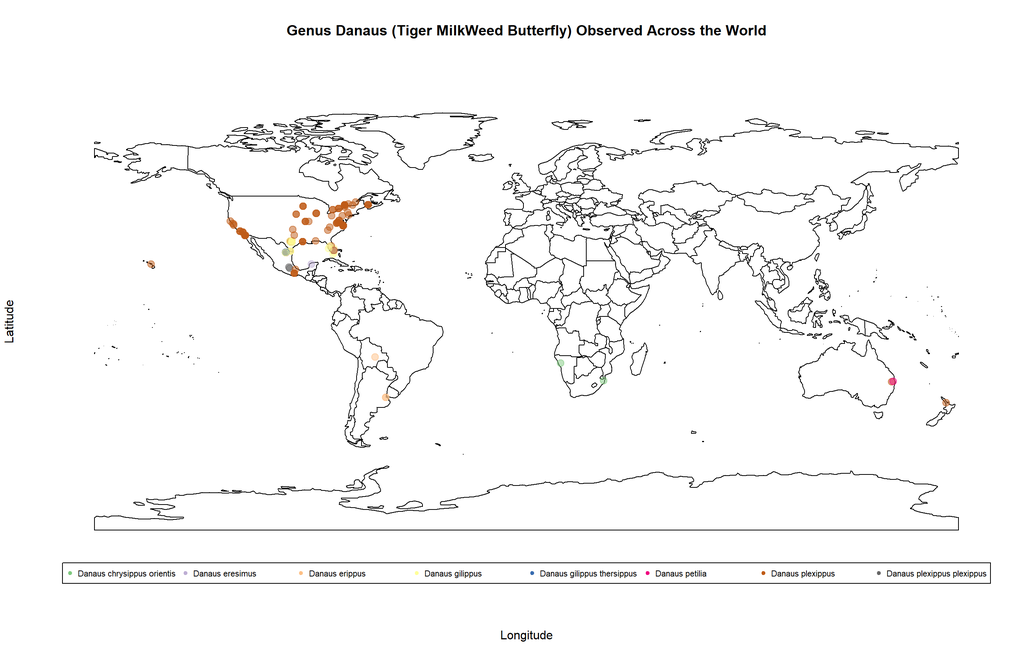

```r
# create map
plot(getMap(),
     xlab = "Longitude",
     ylab = "Latitude",
     main = 'Genus Danaus (Tiger MilkWeed Butterfly) Observed Across the World')

# add data points to map
points(butterfly_data_scatter$longitude, butterfly_data_scatter$latitude,
       col=alpha(jColors$color[match(butterfly_data_scatter$scientific_name, jColors$scientific_name)],0.5),
       pch=19,cex=1.3)

# add legend to map
legend("bottom", inset=c(0,0),
       legend = as.character(jColors$scientific_name),
       col = jColors$color, pch = 19, cex=0.7,
       xpd=TRUE, horiz=T)
```

A high proportion of observations comes from the United States, in particular of the species Danaus plexippus. Additionally, there is a lack of samples from the eastern continents in the world. Even with this disparity in available data, we still observe differences in the distribution of Danaus species spread across the globe. For example, we see that Danaus petilia is only observed in Australia in this data set. This species is typically found in Australia and tropical countries.

## Statistical Tests

### Chi-squared goodness of fit test for metamorphic stages

Based on the number of samples for each metamorphic stage in our data set, we decided to test the null hypothesis that there is no fit between the proportion of samples in each stage that we see and the expected metamorphic stage durations. This will tell us if our stage data is skewed. Because it is categorical data, we conducted a Chi-squared goodness of fit test.

First, we found the average duration of butterflies’ metamorphic stages at: https://www.joyfulbutterfly.com/life-cycle-of-a-butterfly/

We make the assumption that the following information applies for genus Danaus across the world, time, and species.

```
# butterfly life cycle

Egg:               5 days                              5/57.5 = 0.08695652

Caterpillar:       3.5 weeks = 24.5 days               24.5/57.5 = 0.426087

Chrysalis/Pupa:    1.5 weeks = 10.5 days               10.5/57.5 = 0.1826087

Adult butterfly:   2.5 weeks = 17.5 days               17.5/57.5 = 0.3043478

Total lifecycle:   5+24.5+10.5+17.5 = 57.5 days
```

```r
chisq.test(table(butterfly_data$metamorphosis_stage), p = c(5, 24.5, 10.5, 17.5)/57.5)
```

```
##
##  Chi-squared test for given probabilities
##
## data:  table(butterfly_data$metamorphosis_stage)
## X-squared = 927.92, df = 3, p-value < 2.2e-16
```

### Linear regression for observation month vs. latitude

In the “Metamorphic stage of sample compared to observation date” section, we suggested that the apparent bimodal distribution of observations by month may be caused by a connection between observation month and observation location. Here, we hypothesize that a sample’s observation month is related to the latitude of the observation location, because butterflies are most active in warm weather.

```r
# linear regression test
lr <- lm(butterfly_data$month~butterfly_data$latitude)
summary(lr)
```

```
##
## Call:
## lm(formula = butterfly_data$month ~ butterfly_data$latitude)
##
## Residuals:
##    Min     1Q Median     3Q    Max
## -6.402 -1.431  0.415  1.825  6.211
##
## Coefficients:
##                         Estimate Std. Error t value Pr(>|t|)
## (Intercept)              6.59720    0.45830  14.395   <2e-16 ***
## butterfly_data$latitude  0.02192    0.01321   1.659   0.0991 .
## ---
## Signif. codes:  0 '***' 0.001 '**' 0.01 '*' 0.05 '.' 0.1 ' ' 1
##
## Residual standard error: 2.57 on 148 degrees of freedom
## Multiple R-squared:  0.01827,    Adjusted R-squared:  0.01163
## F-statistic: 2.754 on 1 and 148 DF,  p-value: 0.09914
```

## Summary of Results

### Contribution Summary

Kate Skocelas created the metamorphic stages plot and the stages by month and year plots. She also conducted the linear regression test. Julia Zheng created the positional accuracy plots and the world map plot. She also conducted the chi-squared goodness of fit test.